# Results of the agent based model simulating plankton displacement

Author

Thelma Panaïotis

## Load data

```r
# Simulation results
sim_res <- read_parquet("data/12b.simulation_results.parquet")

# Kuiper stat for null dataset
load("data/04b.null_ks.Rdata")
```

## Checks for null distances

### Compare null of each parameter set

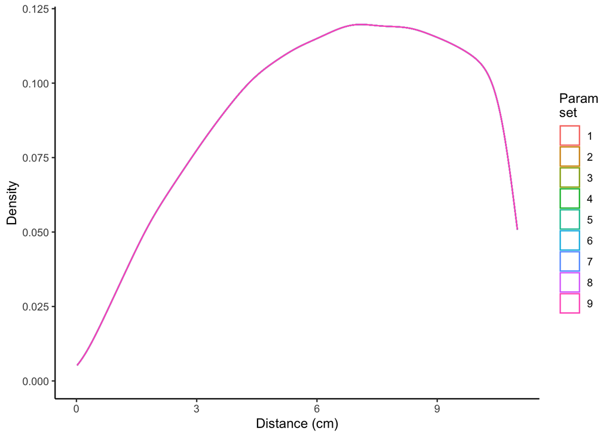

```r
# Extract distances before displacement, i.e. null distances
sim_res_null <- sim_res %>% filter(when == "before") %>% select(-c(p1, p2, prop_mv))

# Extract quantiles for each parameter set
sim_res_null_qt <- sim_res_null %>%
  group_by(d_length, h) %>%
  summarise(dist_qt = list(quantile(dist, probs = probs, names = FALSE))) %>%
  ungroup() %>%
  mutate(param_set = row_number() %>% as.factor())

ggplot(sim_res_null_qt %>% unnest(dist_qt)) +
  geom_density(aes(x = dist_qt, colour = param_set), alpha = 0.2) +
  labs(x = "Distance (cm)", y = "Density", colour = "Param\nset") +
  theme_classic()
```

**Note**

This is expected as all models use the same original points.

### Compare observations null and model null

There are much more observation null distances (>10⁸) than modeled null distances (~300,000). Perform the comparison with:

- quantiles computed from all distances
- quantiles computed from a random subsample of size 300,000 of all distances

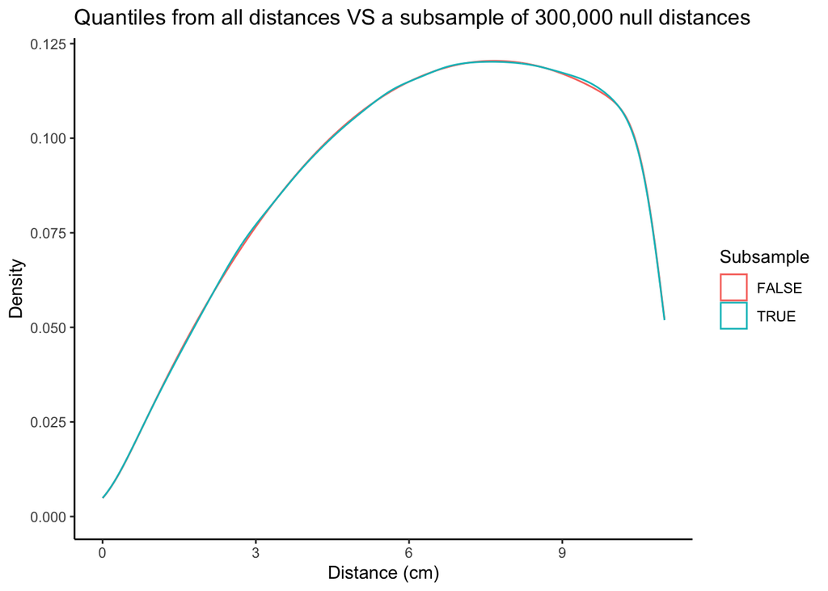

```r
# Read null distances
rand_dist <- read_parquet("data/distances/02a.all_distances_random.parquet") %>%
  filter(dist < dist_thr) # filter distances using threshold

# Without subsampling
rand_dist_qt <- rand_dist %>%
  reframe(dist_qt = quantile(dist, probs = probs, names = FALSE))


# Subsample
rand_dist_sub_qt <- rand_dist %>%
  slice_sample(n = 300000) %>%
  reframe(dist_qt = quantile(dist, probs = probs, names = FALSE))

# Plot quantiles from all distances and from subsampled null distances
bind_rows(
  tibble(dist_qt = rand_dist_qt$dist_qt, subsample = FALSE),
  tibble(dist_qt = rand_dist_sub_qt$dist_qt, subsample = TRUE)
) %>%
  ggplot() +
  geom_density(aes(x = dist_qt, colour = subsample)) +
  labs(x = "Distance (cm)", y = "Density", colour = "Subsample") +
  ggtitle("Quantiles from all distances VS a subsample of 300,000 null distances") +
  theme_classic()
```

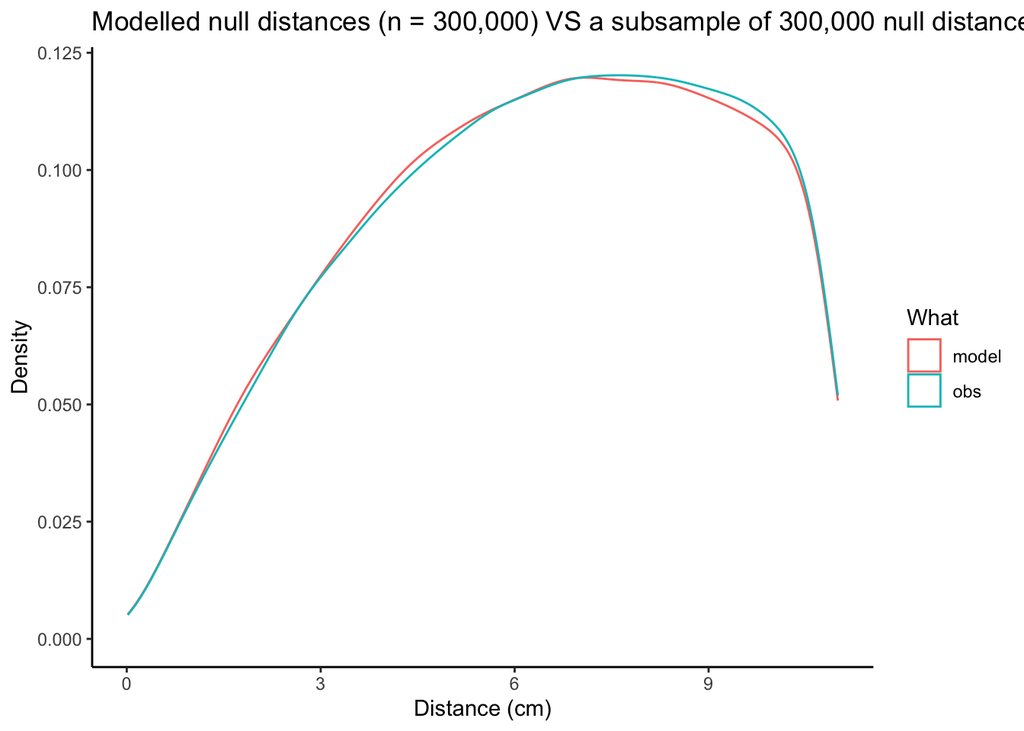

```r
# Plot modelled null distances (n = 300,000) VS a subsample of 300,000 null distances
sim_res_null_qt %>%
  slice(1) %>%
  unnest(dist_qt) %>%
  mutate(what = "model") %>%
  select(dist_qt, what) %>%
  bind_rows(rand_dist_sub_qt %>% mutate(what = "obs")) %>%
  ggplot() +
  geom_density(aes(x = dist_qt, colour = what)) +
  labs(x = "Distance (cm)", y = "Density", colour = "What") +
  ggtitle("Modelled null distances (n = 300,000) VS a subsample of 300,000 null distances") +
  theme_classic()
```

There is some differences between modeled null (n = 300,000) distances and a subsample of 300,000 null distances. This is likely because of the low number of modeled distances. Let’s check if there is variation between various subsamples of 300,000 null distances.

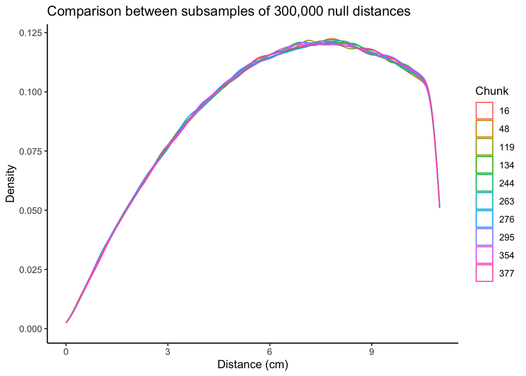

```r
rand_dist %>%
  # generate chunks of 300,000 distances
  mutate(chunk = rep(1:440, each = 300000)[1:nrow(.)]) %>%
  # randomly select 10 of them
  filter(chunk %in% round(runif(n = 10, min = 1, max = 440))) %>%
  mutate(chunk = as.factor(chunk)) %>% # chunk as factor
  ggplot() +
  geom_density(aes(x = dist, colour = chunk)) +
  labs(x = "Distance (cm)", y = "Density", colour = "Chunk") +
  ggtitle("Comparison between subsamples of 300,000 null distances") +
  theme_classic()
```

Indeed, there is variation introduced by subsampling.

**Important**

What do we do?

## Model results

### Process model results

For each set of parameters, extract 10000 quantiles and compute Kuiper stat.

```r
# Split dataframe by set of parameters
sim_res_gr <- sim_res %>%
  select(-c(p1, p2)) %>%
  group_by(d_length, prop_mv, h) %>%
  group_split()

# Loop over sets of parameters
sim_res_ks <- lapply(sim_res_gr, function(el) {
  # Exract distances
  dist_after <- el %>% filter(when == "after") %>% pull(dist)
  dist_before <- el %>% filter(when == "before") %>% pull(dist)
  n_dist_after <- length(dist_after)
  n_dist_before <- length(dist_before)

  # Extract quantiles if needed
  if (length(dist_after) > 10000) {
    dist_after <- quantile(dist_after, probs = probs, names = FALSE)
  }
  if (length(dist_before) > 10000) {
    dist_before <- quantile(dist_before, probs = probs, names = FALSE)
  }

  # Compute Kuiper stat
  kt <- kuiper_stat(dist_before, dist_after)

  # Format results
  res <- tibble(
    d_length = el$d_length[1], # displacement length
    prop_mv = el$prop_mv[1], # proportion of motile organisms
    h = el$h[1], # density sensitivity
    n_dist_after = n_dist_after, # Number of distances after
    n_dist_before = n_dist_before, # Number of distances before
    n_dist = (n_dist_after + n_dist_before) / 2, # Averaged number of distances
    kuiper_stat = kt, # Kuiper statistic
    dist_before_qt = list(dist_before), # quantiles for distances before
    dist_after_qt = list(dist_after) # quantiles for distances after
  )
  return(res)
}) %>%
  bind_rows()

# Keep one table with distances
sim_res_dist <- sim_res_ks %>%
  select(d_length, prop_mv, h, dist_before_qt, dist_after_qt) %>%
  unnest(c(dist_before_qt, dist_after_qt)) %>%
  pivot_longer(dist_before_qt:dist_after_qt, names_to = "when", values_to = "dist") %>%
  mutate(when = ifelse(str_detect(when, "before"), "before", "after"))

# And one without distances
sim_res_ks <- sim_res_ks %>%
  select(-c(dist_before_qt, dist_after_qt)) %>%
  mutate(
    log_n_dist = log10(n_dist),
    log_kuiper_stat = log10(kuiper_stat)
  )
```

### Distances for each parameter set

Let’s now have a look at the model results for the different set of parameters.

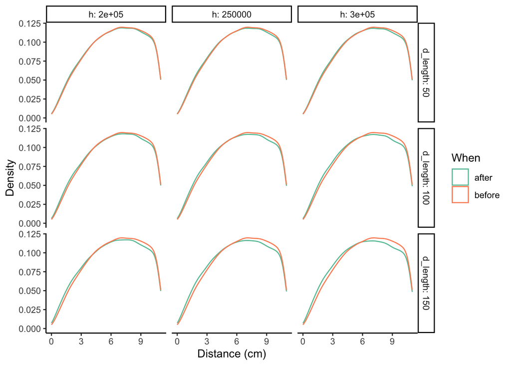

```r
## Plot distances
ggplot(sim_res_dist) +
  geom_density(aes(x = dist, colour = when)) +
  scale_colour_manual(values = c("#66c2a5", "#fc8d62")) +
  labs(x = "Distance (cm)", y = "Density", colour = "When") +
  theme_classic() +
  facet_grid(d_length~h, labeller = labeller(.rows = label_both, .cols = label_both))
```

Let’s also plot ECDFs.

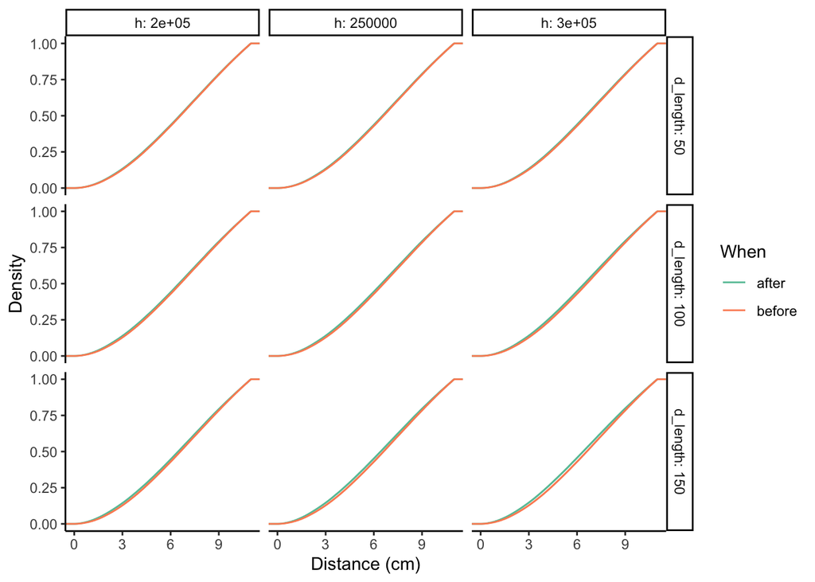

```r
ggplot(sim_res_dist) +
  stat_ecdf(aes(x = dist, colour = when)) +
  scale_colour_manual(values = c("#66c2a5", "#fc8d62")) +
  labs(x = "Distance (cm)", y = "Density", colour = "When") +
  theme_classic() +
  facet_grid(d_length~h, labeller = labeller(.rows = label_both, .cols = label_both))
```

We clearly see that the choice of parameter affects the distribution of distances after displacement. Let’s plot Kuiper statistic for each set of parameters.

### Plot Kuiper statistic

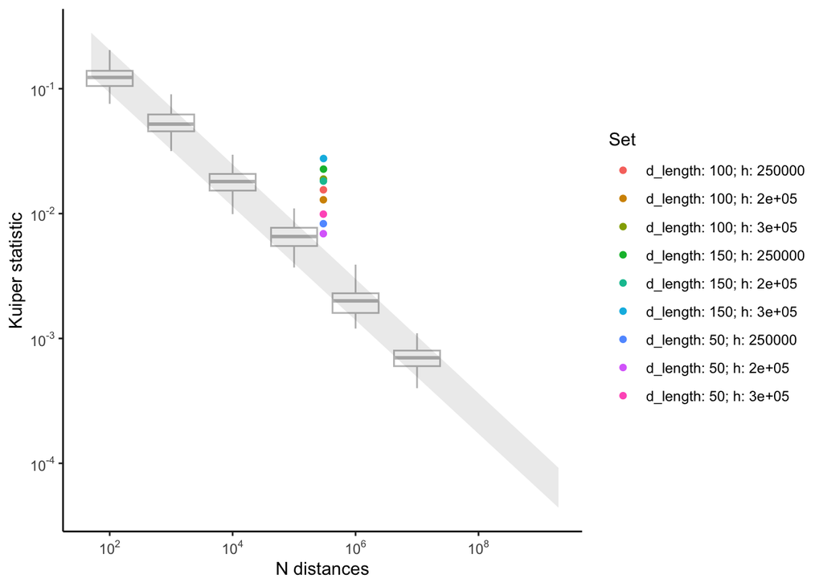

```r
sim_res_ks <- sim_res_ks %>%
  mutate(set = paste0("d_length: ", d_length, "; h: ", h) %>% as.factor()) # create one column for all parameters

ggplot() +
  geom_boxplot(data = null_ks_n_dist, aes(x = log_n_dist, y = log_kuiper_stat, group = log_n_dist), colour = "gray", outlier.shape = NA) +
  geom_polygon(data = null_ks_rib, aes(x = log_n_dist, y = y), alpha = 0.1) +
  geom_point(data = sim_res_ks, aes(x = log_n_dist, y = log_kuiper_stat, colour = set)) +
  labs(x = "N distances", y = "Kuiper statistic", colour = "Set") +
  scale_x_continuous(labels = label_math(expr = 10^.x, format = force), breaks = seq(2, 8, by = 2)) +
  scale_y_continuous(labels = label_math(expr = 10^.x, format = force)) +
  theme_classic()
```

The Kuiper statistic does vary with the parameter set. Let’s now compare with observations.

### Compare with observations

First, we need to subsample observations to match the number of distances, and then compute Kuiper statistic.

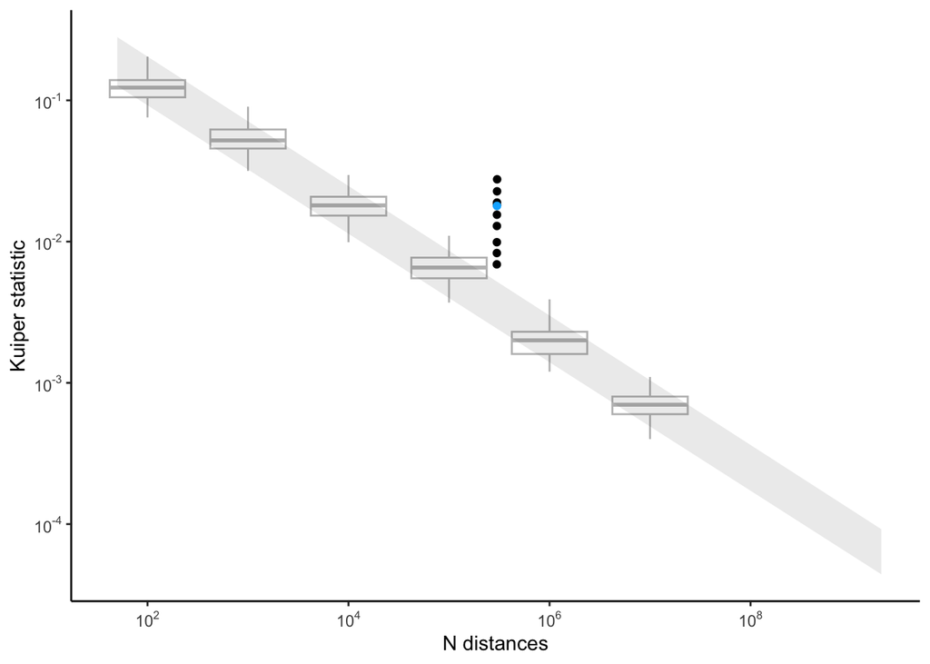

```r
# Read plankton distances
plank_dist <- read_parquet("data/distances/02a.all_distances_plankton.parquet")

# Filter distances using threshold
plank_dist <- plank_dist %>% filter(dist < dist_thr)

# Subsample: we want ~300000 distances to match the number of distances from the model.
plank_dist_sub <- plank_dist %>% slice_sample(n = 300000)
rand_dist_sub <- rand_dist %>% slice_sample(n = 300000)

# Get quantiles
plank_qt <- quantile(plank_dist_sub$dist, probs = probs, names = FALSE)
rand_qt <- quantile(rand_dist_sub$dist, probs = probs, names = FALSE)

# Kuiper statistic
ks <- kuiper_stat(plank_qt, rand_qt)

# Store results
obs_ks <- tibble(
  n_dist_plank = nrow(plank_dist_sub),
  n_dist_rand = nrow(rand_dist_sub),
  n_dist = (nrow(plank_dist_sub) + nrow(rand_dist_sub)) / 2,
  plank_qt = list(plank_qt),
  rand_qt = list(rand_qt),
  kuiper_stat = ks
) %>%
  mutate(
    log_n_dist = log10(n_dist),
    log_kuiper_stat = log10(kuiper_stat)
  )

# Plot observation Kuiper statistic with model KS
ggplot() +
  geom_boxplot(data = null_ks_n_dist, aes(x = log_n_dist, y = log_kuiper_stat, group = log_n_dist), colour = "gray", outlier.shape = NA) +
  geom_polygon(data = null_ks_rib, aes(x = log_n_dist, y = y), alpha = 0.1) +
  geom_point(data = sim_res_ks, aes(x = log_n_dist, y = log_kuiper_stat)) +
  geom_point(data = obs_ks, aes(x = log_n_dist, y = log_kuiper_stat), colour = "#00B2FF") +
  labs(x = "N distances", y = "Kuiper statistic") +
  scale_x_continuous(labels = label_math(expr = 10^.x, format = force), breaks = seq(2, 8, by = 2)) +
  scale_y_continuous(labels = label_math(expr = 10^.x, format = force)) +
  theme_classic()
```

It seems that model parameters do cover the observations Kuiper statistic. Let’s find the best model.

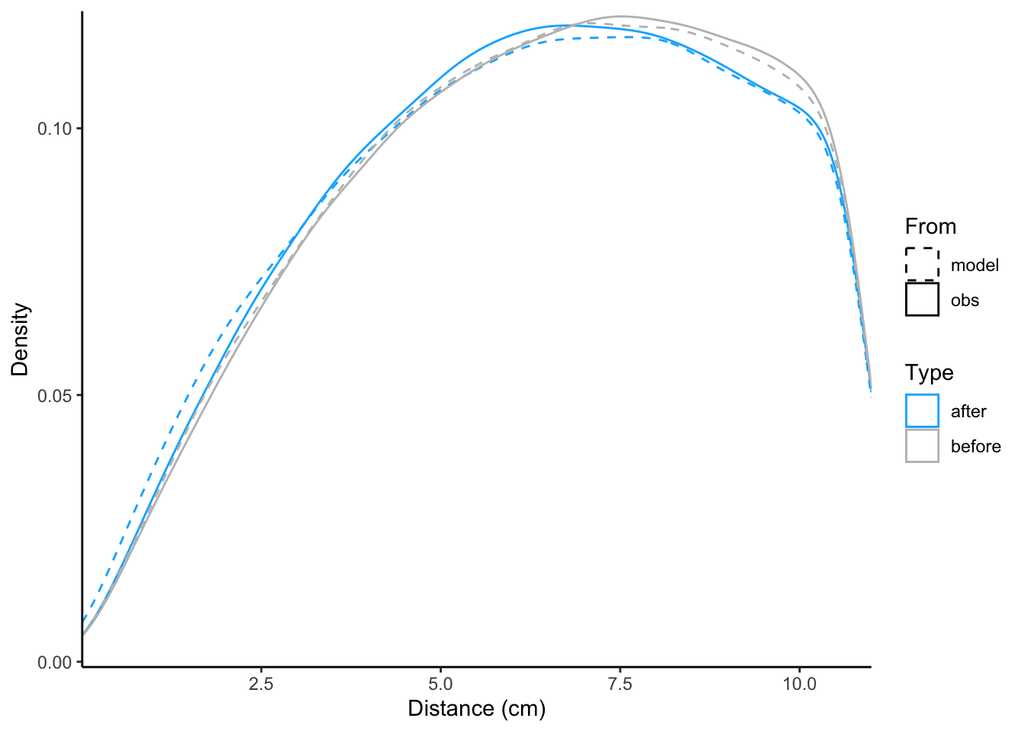

```r
# Identify parameter set with the closest KS to observations KS
sim_sel <- sim_res_ks %>%
  mutate(
    obs_kuiper_stat = obs_ks$kuiper_stat,
    diff_kuiper_stat = abs(kuiper_stat - obs_kuiper_stat)
    ) %>%
  filter(diff_kuiper_stat == min(diff_kuiper_stat))

# Get model distances corresponding to selected set of parameters
mod_dist <- sim_sel %>%
  left_join(sim_res_dist, by = join_by(d_length, prop_mv, h)) %>%
  mutate(what = "model")

# Observation distances
obs_dist <- tibble(
  what = "obs",
  when = "before",
  dist = rand_qt
) %>%
  bind_rows(
    tibble(
      what = "obs",
      when = "after",
      dist = plank_qt
    )
  )

# Bind together
all_dist <- bind_rows(
  mod_dist,
  obs_dist
)

# Plot model and observations for before and after
ggplot(all_dist) +
  geom_density(aes(x = dist, colour = when, linetype = what)) +
  scale_colour_manual(values = c("#00B2FF", "grey"))+#, labels = c("Plankton", "Null")) +
  scale_linetype_manual(values = c("dashed", "solid")) +
  labs(x = "Distance (cm)", y = "Density", colour = "Type", linetype = "From") +
  scale_x_continuous(expand = c(0, 0)) +
  scale_y_continuous(expand = c(0, 0.001), breaks = c(0, 0.05, 0.10)) +
  theme_classic()
```

Selected parameters are:

Ideally, continuous and dotted lines should be identical.

### Compare with observations: second method

Here, we compute Kuiper statistic between modeled distances after and observations.

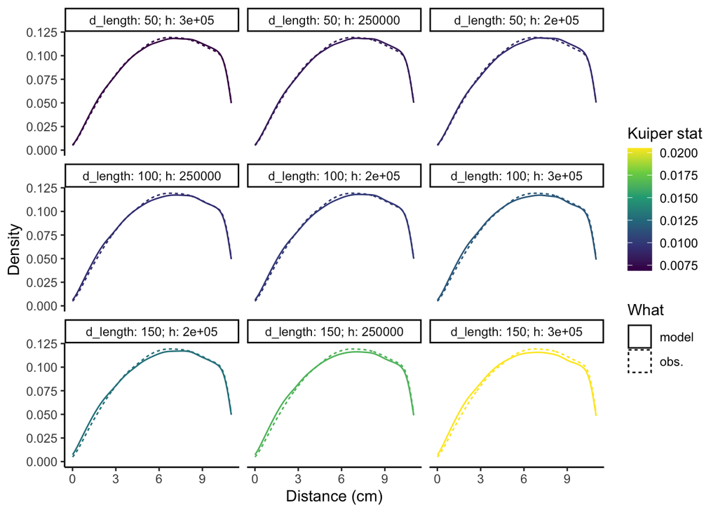

```r
# Get observations quantiles
plank_dist_sub_qt <- quantile(plank_dist_sub$dist, probs = probs, names = FALSE)

# Loop over sets of parameters
sim_vs_obs_ks <- lapply(sim_res_gr, function(el) {
  # Exract distances
  dist_mod <- el %>% filter(when == "after") %>% pull(dist)
  n_dist_mod <- length(dist_mod)

  # Extract quantiles
  dist_mod_qt <- quantile(dist_mod, probs = probs, names = FALSE)

  # Compute Kuiper stat
  kt <- kuiper_stat(dist_mod_qt, plank_dist_sub_qt)

  # Format results
  res <- tibble(
    d_length = el$d_length[1], # displacement length
    prop_mv = el$prop_mv[1], # proportion of motile organisms
    h = el$h[1], # density sensitivity
    n_dist_mod = n_dist_mod, # Number of modelled distances
    n_dist_obs = nrow(plank_dist_sub), # Number of observed distances
    n_dist = (n_dist_mod + n_dist_obs) / 2, # Averaged number of distances
    kuiper_stat = kt, # Kuiper statistic
    dist_mod_qt = list(dist_mod_qt), # quantiles for modelled distances
    dist_obs_qt = list(plank_dist_sub_qt) # quantiles for observed distances
  )
  return(res)
}) %>%
  bind_rows()


sim_vs_obs_ks %>%
  arrange(kuiper_stat) %>%
  mutate(set = paste0("d_length: ", d_length, "; h: ", h) %>% fct_inorder()) %>%
  select(set, kuiper_stat, dist_mod_qt, dist_obs_qt) %>%
  unnest(c(dist_mod_qt, dist_obs_qt)) %>%
  pivot_longer(dist_mod_qt:dist_obs_qt) %>%
  mutate(name = ifelse(str_detect(name, "mod"), "model", "obs.")) %>%
  ggplot() +
  geom_density(aes(x = value, linetype = name, colour = kuiper_stat)) +
  scale_colour_viridis_c() +
  labs(x = "Distance (cm)", y = "Density", colour = "Kuiper stat", linetype = "What") +
  theme_classic() +
  facet_wrap(~set)
```